# Lab 9 - Incomplete designs

Daniel Runcie. Modified from labs designed by Iago Hale, Dario Cantu and Jorge Dubcovsky

## Incomplete block design

The analysis of incomplete block designs is very similar to the analysis of complete block designs. You still need to specify a model with all blocking terms, declare any random terms, and ask for specific contrasts using `emmeans`.

There are only two main differences between analyses of complete and incomplete block designs:

1. The order of terms in the model matters for incomplete block designs. **always put blocking factors first, treatments last**
2. Declaring blocks **random** does affect the analysis of incomplete blocks, even if there are no replicates of any treatment in each block

As an example, we’ll analyze data from a classic experiment investigating soybean yield in Ames, Iowa in 1937. The experiment consisted of 31 varieties tested in a single field, which was divided into 31 incomplete blocks. Each block contained 6 plots.

```r
soybeans = read.csv('soybean.csv',colClasses = c('factor','factor','numeric'))  # you can directly assign column classes (factor / numeric) when you load the data if you know what the data will look like
str(soybeans)
```

```
'data.frame':   186 obs. of  3 variables:
 $ block: Factor w/ 31 levels "B01","B02","B03",..: 1 2 3 4 5 6 7 8 9 10 ...
 $ gen  : Factor w/ 31 levels "G01","G02","G03",..: 24 15 20 18 20 5 22 1 9 14 ...
 $ yield: num  29.8 24.2 30.5 20 35.2 25 23.6 23.6 29.3 25.5 ...
```

### Visualsing the design

With a blocked design, a table that counts the number of occurences of each treatment in each block can help visualize the experiment. The `table` function counts the number of occurences of each combination of the listed factors. This is called an **incidence matrix** for the design

```r
incidence_mat = table(soybeans$block,soybeans$gen)
incidence_mat
```

```
      G01 G02 G03 G04 G05 G06 G07 G08 G09 G10 G11 G12 G13 G14 G15 G16 G17 G18 G19 G20 G21 G22 G23 G24 G25 G26 G27 G28 G29 G30 G31
  B01   0   0   0   0   0   0   0   0   0   0   0   0   0   0   0   0   0   0   0   0   1   1   1   1   1   1   0   0   0   0   0
  B02   0   0   0   0   0   0   0   0   0   0   1   1   1   1   1   0   0   0   0   0   0   0   0   0   0   1   0   0   0   0   0
  B03   0   0   1   0   0   0   1   0   0   0   1   0   0   0   0   0   0   0   0   1   0   0   0   1   0   0   0   1   0   0   0
  B04   0   0   0   1   0   0   1   0   0   0   0   0   0   0   1   0   0   1   0   0   1   0   0   0   0   0   0   0   1   0   0
  B05   0   0   0   0   1   0   0   0   0   1   0   0   0   0   1   0   0   0   0   1   0   0   0   0   1   0   1   0   0   0   0
  B06   0   0   0   0   1   0   0   1   0   0   1   0   0   0   0   0   0   0   1   0   0   1   0   0   0   0   0   0   1   0   0
  B07   0   1   0   0   0   0   1   0   0   0   0   1   0   0   0   0   1   0   0   0   0   1   0   0   0   0   1   0   0   0   0
  B08   1   1   1   1   1   0   0   0   0   0   0   0   0   0   0   0   0   0   0   0   0   0   0   0   0   1   0   0   0   0   0
  B09   0   0   1   0   0   0   0   0   1   0   0   0   0   0   1   1   0   0   0   0   0   1   0   0   0   0   0   0   0   0   1
  B10   0   0   1   0   0   1   0   0   0   0   0   0   0   1   0   0   1   0   0   0   0   0   0   0   1   0   0   0   1   0   0
  B11   0   0   0   1   0   0   0   0   0   1   1   0   0   0   0   0   1   0   0   0   0   0   1   0   0   0   0   0   0   0   1
  B12   0   0   0   0   0   0   0   0   0   0   0   0   0   0   0   1   1   1   1   1   0   0   0   0   0   1   0   0   0   0   0
  B13   0   0   1   0   0   0   0   1   0   0   0   0   1   0   0   0   0   1   0   0   0   0   1   0   0   0   1   0   0   0   0
  B14   0   0   0   0   1   1   0   0   0   0   0   1   0   0   0   0   0   1   0   0   0   0   0   1   0   0   0   0   0   0   1
  B15   0   0   0   0   1   0   0   0   1   0   0   0   1   0   0   0   1   0   0   0   1   0   0   0   0   0   0   1   0   0   0
  B16   0   1   0   0   0   0   0   0   0   1   0   0   1   0   0   1   0   0   0   0   0   0   0   1   0   0   0   0   1   0   0
  B17   1   0   0   0   0   0   0   1   0   0   0   0   0   0   1   0   1   0   0   0   0   0   0   1   0   0   0   0   0   1   0
  B18   1   0   0   0   0   0   0   0   0   1   0   0   0   1   0   0   0   1   0   0   0   1   0   0   0   0   0   1   0   0   0
  B19   1   0   0   0   0   1   0   0   0   0   1   0   0   0   0   1   0   0   0   0   1   0   0   0   0   0   1   0   0   0   0
  B20   0   1   0   0   0   1   0   0   0   0   0   0   0   0   1   0   0   0   1   0   0   0   1   0   0   0   0   1   0   0   0
  B21   0   0   0   1   0   0   0   1   0   0   0   1   0   0   0   1   0   0   0   0   0   0   0   0   1   0   0   1   0   0   0
  B22   0   0   0   0   0   1   1   1   1   1   0   0   0   0   0   0   0   0   0   0   0   0   0   0   0   1   0   0   0   0   0
  B23   0   0   1   0   0   0   0   0   0   1   0   1   0   0   0   0   0   0   1   0   1   0   0   0   0   0   0   0   0   1   0
  B24   0   0   0   0   1   0   1   0   0   0   0   0   0   1   0   1   0   0   0   0   0   0   1   0   0   0   0   0   0   1   0
  B25   0   0   0   1   0   0   0   0   1   0   0   0   0   1   0   0   0   0   1   0   0   0   0   1   0   0   1   0   0   0   0
  B26   0   0   0   0   0   0   0   0   0   0   0   0   0   0   0   0   0   0   0   0   0   0   0   0   0   1   1   1   1   1   1
  B27   0   1   0   0   0   0   0   0   1   0   1   0   0   0   0   0   0   1   0   0   0   0   0   0   1   0   0   0   0   1   0
  B28   0   1   0   0   0   0   0   1   0   0   0   0   0   1   0   0   0   0   0   1   1   0   0   0   0   0   0   0   0   0   1
  B29   1   0   0   0   0   0   1   0   0   0   0   0   1   0   0   0   0   0   1   0   0   0   0   0   1   0   0   0   0   0   1
  B30   1   0   0   0   0   0   0   0   1   0   0   1   0   0   0   0   0   0   0   1   0   0   1   0   0   0   0   0   1   0   0
  B31   0   0   0   1   0   1   0   0   0   0   0   0   1   0   0   0   0   0   0   1   0   1   0   0   0   0   0   0   0   1   0
```

We can also plot table table with the `plot()` function:

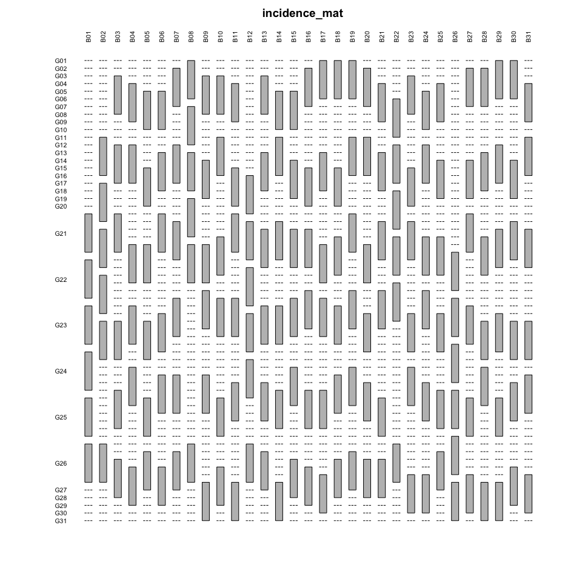

```r
plot(incidence_mat,las=2)
```

**Note**: I expanded the size of the figure by adding `{r,fig.width=10,fig.height=10}` to the beginning of the code chunk

### Inspecting balance

One use of the incidence matrix is to calculate the number of times each pair of treatments occurs together in the same block. This is easily calculated from the incidence matrix like this:

```r
crossprod(incidence_mat)
```

```
      G01 G02 G03 G04 G05 G06 G07 G08 G09 G10 G11 G12 G13 G14 G15 G16 G17 G18 G19 G20 G21 G22 G23 G24 G25 G26 G27 G28 G29 G30 G31
  G01   6   1   1   1   1   1   1   1   1   1   1   1   1   1   1   1   1   1   1   1   1   1   1   1   1   1   1   1   1   1   1
  G02   1   6   1   1   1   1   1   1   1   1   1   1   1   1   1   1   1   1   1   1   1   1   1   1   1   1   1   1   1   1   1
  G03   1   1   6   1   1   1   1   1   1   1   1   1   1   1   1   1   1   1   1   1   1   1   1   1   1   1   1   1   1   1   1
  G04   1   1   1   6   1   1   1   1   1   1   1   1   1   1   1   1   1   1   1   1   1   1   1   1   1   1   1   1   1   1   1
  G05   1   1   1   1   6   1   1   1   1   1   1   1   1   1   1   1   1   1   1   1   1   1   1   1   1   1   1   1   1   1   1
  G06   1   1   1   1   1   6   1   1   1   1   1   1   1   1   1   1   1   1   1   1   1   1   1   1   1   1   1   1   1   1   1
  G07   1   1   1   1   1   1   6   1   1   1   1   1   1   1   1   1   1   1   1   1   1   1   1   1   1   1   1   1   1   1   1
  G08   1   1   1   1   1   1   1   6   1   1   1   1   1   1   1   1   1   1   1   1   1   1   1   1   1   1   1   1   1   1   1
  G09   1   1   1   1   1   1   1   1   6   1   1   1   1   1   1   1   1   1   1   1   1   1   1   1   1   1   1   1   1   1   1
  G10   1   1   1   1   1   1   1   1   1   6   1   1   1   1   1   1   1   1   1   1   1   1   1   1   1   1   1   1   1   1   1
  G11   1   1   1   1   1   1   1   1   1   1   6   1   1   1   1   1   1   1   1   1   1   1   1   1   1   1   1   1   1   1   1
  G12   1   1   1   1   1   1   1   1   1   1   1   6   1   1   1   1   1   1   1   1   1   1   1   1   1   1   1   1   1   1   1
  G13   1   1   1   1   1   1   1   1   1   1   1   1   6   1   1   1   1   1   1   1   1   1   1   1   1   1   1   1   1   1   1
  G14   1   1   1   1   1   1   1   1   1   1   1   1   1   6   1   1   1   1   1   1   1   1   1   1   1   1   1   1   1   1   1
  G15   1   1   1   1   1   1   1   1   1   1   1   1   1   1   6   1   1   1   1   1   1   1   1   1   1   1   1   1   1   1   1
  G16   1   1   1   1   1   1   1   1   1   1   1   1   1   1   1   6   1   1   1   1   1   1   1   1   1   1   1   1   1   1   1
  G17   1   1   1   1   1   1   1   1   1   1   1   1   1   1   1   1   6   1   1   1   1   1   1   1   1   1   1   1   1   1   1
  G18   1   1   1   1   1   1   1   1   1   1   1   1   1   1   1   1   1   6   1   1   1   1   1   1   1   1   1   1   1   1   1
  G19   1   1   1   1   1   1   1   1   1   1   1   1   1   1   1   1   1   1   6   1   1   1   1   1   1   1   1   1   1   1   1
  G20   1   1   1   1   1   1   1   1   1   1   1   1   1   1   1   1   1   1   1   6   1   1   1   1   1   1   1   1   1   1   1
  G21   1   1   1   1   1   1   1   1   1   1   1   1   1   1   1   1   1   1   1   1   6   1   1   1   1   1   1   1   1   1   1
  G22   1   1   1   1   1   1   1   1   1   1   1   1   1   1   1   1   1   1   1   1   1   6   1   1   1   1   1   1   1   1   1
  G23   1   1   1   1   1   1   1   1   1   1   1   1   1   1   1   1   1   1   1   1   1   1   6   1   1   1   1   1   1   1   1
  G24   1   1   1   1   1   1   1   1   1   1   1   1   1   1   1   1   1   1   1   1   1   1   1   6   1   1   1   1   1   1   1
  G25   1   1   1   1   1   1   1   1   1   1   1   1   1   1   1   1   1   1   1   1   1   1   1   1   6   1   1   1   1   1   1
  G26   1   1   1   1   1   1   1   1   1   1   1   1   1   1   1   1   1   1   1   1   1   1   1   1   1   6   1   1   1   1   1
  G27   1   1   1   1   1   1   1   1   1   1   1   1   1   1   1   1   1   1   1   1   1   1   1   1   1   1   6   1   1   1   1
  G28   1   1   1   1   1   1   1   1   1   1   1   1   1   1   1   1   1   1   1   1   1   1   1   1   1   1   1   6   1   1   1
  G29   1   1   1   1   1   1   1   1   1   1   1   1   1   1   1   1   1   1   1   1   1   1   1   1   1   1   1   1   6   1   1
  G30   1   1   1   1   1   1   1   1   1   1   1   1   1   1   1   1   1   1   1   1   1   1   1   1   1   1   1   1   1   6   1
  G31   1   1   1   1   1   1   1   1   1   1   1   1   1   1   1   1   1   1   1   1   1   1   1   1   1   1   1   1   1   1   6
```

This table counts the number of times each pair of genotypes (columns of `incidence_mat`) occurs together in the same block (rows of `incidence_mat`).

> As you can see from this matrix, the design is balanced, with lambda=1. Each pair of treatments occurs in the same block exactly once.

### Consequences of lost blocks

To explore these functions, say Blocks `B01`, `B02` and `B03` were lost. Look at the incidence matrix for these blocks:

```r
incidence_mat[1:3,]
```

```
      G01 G02 G03 G04 G05 G06 G07 G08 G09 G10 G11 G12 G13 G14 G15 G16 G17 G18 G19 G20 G21 G22 G23 G24 G25 G26 G27 G28 G29 G30 G31
  B01   0   0   0   0   0   0   0   0   0   0   0   0   0   0   0   0   0   0   0   0   1   1   1   1   1   1   0   0   0   0   0
  B02   0   0   0   0   0   0   0   0   0   0   1   1   1   1   1   0   0   0   0   0   0   0   0   0   0   1   0   0   0   0   0
  B03   0   0   1   0   0   0   1   0   0   0   1   0   0   0   0   0   0   0   0   1   0   0   0   1   0   0   0   1   0   0   0
```

Using `crossprod`, we can see how this would affect the balance of the whole experiment

```r
soybeans_lostBlocks = subset(soybeans,block %in% c('B01','B02','B03') == F)
incidence_mat_lost_blocks = table(soybeans_lostBlocks$block,soybeans_lostBlocks$gen)
crossprod(incidence_mat_lost_blocks)
```

```
      G01 G02 G03 G04 G05 G06 G07 G08 G09 G10 G11 G12 G13 G14 G15 G16 G17 G18 G19 G20 G21 G22 G23 G24 G25 G26 G27 G28 G29 G30 G31
  G01   6   1   1   1   1   1   1   1   1   1   1   1   1   1   1   1   1   1   1   1   1   1   1   1   1   1   1   1   1   1   1
  G02   1   6   1   1   1   1   1   1   1   1   1   1   1   1   1   1   1   1   1   1   1   1   1   1   1   1   1   1   1   1   1
  G03   1   1   5   1   1   1   0   1   1   1   0   1   1   1   1   1   1   1   1   0   1   1   1   0   1   1   1   0   1   1   1
  G04   1   1   1   6   1   1   1   1   1   1   1   1   1   1   1   1   1   1   1   1   1   1   1   1   1   1   1   1   1   1   1
  G05   1   1   1   1   6   1   1   1   1   1   1   1   1   1   1   1   1   1   1   1   1   1   1   1   1   1   1   1   1   1   1
  G06   1   1   1   1   1   6   1   1   1   1   1   1   1   1   1   1   1   1   1   1   1   1   1   1   1   1   1   1   1   1   1
  G07   1   1   0   1   1   1   5   1   1   1   0   1   1   1   1   1   1   1   1   0   1   1   1   0   1   1   1   0   1   1   1
  G08   1   1   1   1   1   1   1   6   1   1   1   1   1   1   1   1   1   1   1   1   1   1   1   1   1   1   1   1   1   1   1
  G09   1   1   1   1   1   1   1   1   6   1   1   1   1   1   1   1   1   1   1   1   1   1   1   1   1   1   1   1   1   1   1
  G10   1   1   1   1   1   1   1   1   1   6   1   1   1   1   1   1   1   1   1   1   1   1   1   1   1   1   1   1   1   1   1
  G11   1   1   0   1   1   1   0   1   1   1   4   0   0   0   0   1   1   1   1   0   1   1   1   0   1   0   1   0   1   1   1
  G12   1   1   1   1   1   1   1   1   1   1   0   5   0   0   0   1   1   1   1   1   1   1   1   1   1   0   1   1   1   1   1
  G13   1   1   1   1   1   1   1   1   1   1   0   0   5   0   0   1   1   1   1   1   1   1   1   1   1   0   1   1   1   1   1
  G14   1   1   1   1   1   1   1   1   1   1   0   0   0   5   0   1   1   1   1   1   1   1   1   1   1   0   1   1   1   1   1
  G15   1   1   1   1   1   1   1   1   1   1   0   0   0   0   5   1   1   1   1   1   1   1   1   1   1   0   1   1   1   1   1
  G16   1   1   1   1   1   1   1   1   1   1   1   1   1   1   1   6   1   1   1   1   1   1   1   1   1   1   1   1   1   1   1
  G17   1   1   1   1   1   1   1   1   1   1   1   1   1   1   1   1   6   1   1   1   1   1   1   1   1   1   1   1   1   1   1
  G18   1   1   1   1   1   1   1   1   1   1   1   1   1   1   1   1   1   6   1   1   1   1   1   1   1   1   1   1   1   1   1
  G19   1   1   1   1   1   1   1   1   1   1   1   1   1   1   1   1   1   1   6   1   1   1   1   1   1   1   1   1   1   1   1
  G20   1   1   0   1   1   1   0   1   1   1   0   1   1   1   1   1   1   1   1   5   1   1   1   0   1   1   1   0   1   1   1
  G21   1   1   1   1   1   1   1   1   1   1   1   1   1   1   1   1   1   1   1   1   5   0   0   0   0   0   1   1   1   1   1
  G22   1   1   1   1   1   1   1   1   1   1   1   1   1   1   1   1   1   1   1   1   0   5   0   0   0   0   1   1   1   1   1
  G23   1   1   1   1   1   1   1   1   1   1   1   1   1   1   1   1   1   1   1   1   0   0   5   0   0   0   1   1   1   1   1
  G24   1   1   0   1   1   1   0   1   1   1   0   1   1   1   1   1   1   1   1   0   0   0   0   4   0   0   1   0   1   1   1
  G25   1   1   1   1   1   1   1   1   1   1   1   1   1   1   1   1   1   1   1   1   0   0   0   0   5   0   1   1   1   1   1
  G26   1   1   1   1   1   1   1   1   1   1   0   0   0   0   0   1   1   1   1   1   0   0   0   0   0   4   1   1   1   1   1
  G27   1   1   1   1   1   1   1   1   1   1   1   1   1   1   1   1   1   1   1   1   1   1   1   1   1   1   6   1   1   1   1
  G28   1   1   0   1   1   1   0   1   1   1   0   1   1   1   1   1   1   1   1   0   1   1   1   0   1   1   1   5   1   1   1
  G29   1   1   1   1   1   1   1   1   1   1   1   1   1   1   1   1   1   1   1   1   1   1   1   1   1   1   1   1   6   1   1
  G30   1   1   1   1   1   1   1   1   1   1   1   1   1   1   1   1   1   1   1   1   1   1   1   1   1   1   1   1   1   6   1
  G31   1   1   1   1   1   1   1   1   1   1   1   1   1   1   1   1   1   1   1   1   1   1   1   1   1   1   1   1   1   1   6
```

> From this, we can see that the design is no-longer balanced. Some pairs of treatments do not occur in the same block. Also, some treatments only have 4 or 5 reps. With this subset of the data, the precisions of estimates of treatment means and pairwise contrasts will not be all the same.

### Analysis of incomplete blocks

#### Fixed blocks

The main consequence of incomplete blocks for analysis is that the order of terms in the linear model matters, at least for ANOVA, and when blocks are fixed.

The following code compares two models, one with `gen` listed first, and the other with `block` listed first.

```r
lm_genFirst = lm(yield ~ gen + block,soybeans)
anova(lm_genFirst)
```

```
Analysis of Variance Table

Response: yield
           Df  Sum Sq Mean Sq F value    Pr(>F)
gen        30 2559.86  85.329 23.7997 < 2.2e-16 ***
block      30  924.02  30.801  8.5909 < 2.2e-16 ***
Residuals 125  448.16   3.585
---
Signif. codes:  0 ‘***’ 0.001 ‘**’ 0.01 ‘*’ 0.05 ‘.’ 0.1 ‘ ’ 1
```

```r
lm_blockFirst = lm(yield ~ block + gen,soybeans)
anova(lm_blockFirst)
```

```
Analysis of Variance Table

Response: yield
           Df  Sum Sq Mean Sq F value    Pr(>F)
block      30 1642.61  54.754  15.272 < 2.2e-16 ***
gen        30 1841.28  61.376  17.119 < 2.2e-16 ***
Residuals 125  448.16   3.585
---
Signif. codes:  0 ‘***’ 0.001 ‘**’ 0.01 ‘*’ 0.05 ‘.’ 0.1 ‘ ’ 1
```

#### Questions

> Compare the F-values for gen in the two models. Which model identifies larger differences among genotypes?

> Compare the Residuals line. Do the models differ in how well they can explain the data?

Since the models provide exactly the same fits to the data, we cannot use that to decide which model is correct. Notice that the first one assigns more Sum Sq to `gen`, and less Sum Sq to ‘block’ than the second model. This makes the first more optimistic about the effect of `gen` than the second. To be conservative, we’ll use the second model to test the null hypothesis that all genotypes are equivalent.

#### Random blocks

Unlike with a basic RCBD (without reps), for an incomplete block design, declaring blocks to be random will change the results (though usually not that much).

```r
blocks_random = lmer(yield ~ (1|block) + gen,soybeans)
anova(blocks_random,ddf='K')
```

```
Type III Analysis of Variance Table with Kenward-Roger's method
    Sum Sq Mean Sq NumDF  DenDF F value    Pr(>F)
gen 1895.9  63.197    30 129.06  17.627 < 2.2e-16 ***
---
Signif. codes:  0 ‘***’ 0.001 ‘**’ 0.01 ‘*’ 0.05 ‘.’ 0.1 ‘ ’ 1
```

With many blocks, few treatments per block, and small block differences, this random model will tend to be more powerful than the fixed model (ie larger F.value, smaller confidence intervals).

### Comparing means

Means comparisions in incomplete block designs proceed identically to those for complete blocks. I’ll demonstrate for the fixed-blocks model. Since there are many genotypes, I’ll focus on comparisons among just the first three:

```r
trt_means = emmeans(lm_blockFirst,specs = 'gen',at=list(gen = c('G01','G02','G03')))
contrasts = contrast(trt_means,method = 'pairwise')
summary(contrasts,infer = c(T,F))
```

```
 contrast   estimate       SE  df
 G01 - G02 -2.335484 1.178072 125
 G01 - G03 -8.029032 1.178072 125
 G02 - G03 -5.693548 1.178072 125

Results are averaged over the levels of: block
```

### Excercise:

Repeate the above exercises with the following dataset that lost the first three blocks.

Look specifically at the comparisons between G03, G06, G07, G11, and G12. Try to explain why each difference among genotypes has a different standard error.

```r
soybean_missingBlocks = subset(soybeans,block %in% c('B01','B02','B03') == F)
# anova
# means comparisons. Use at=list(gen = c('G03','G06','G07','G11','G12')) to specifify only these genotypes.
```

> Are all standard errors among contrasts the same? Compare the standard errors on the G03-G06, G03-G07, and G11-G12 contrasts.

## Unconnected design

Blocked designs do not need to be complete, or balanced. Balanced designs are often preferred because all treatments are treated equally. But lack of balance doesn’t inherently bias an experiment - it just makes standard errors larger for some contrasts than others.

However, a more serious problem in an experimental design is a lack of **connectedness**. Two treatments are not connected if they are not present in the same block, and there is no other treatment (or treatments) that can serve as a bridge between the first two treatments going through other blocks.

Consider the following dataset:

```r
unconnected_data = read.csv('unconnected.csv',colClasses = c('factor','factor'))
str(unconnected_data)
```

```
'data.frame':   8 obs. of  2 variables:
 $ Block: Factor w/ 4 levels "1","2","3","4": 1 1 2 2 3 3 4 4
 $ Trt  : Factor w/ 4 levels "A","B","C","D": 1 3 2 4 1 3 2 4
```

We can visualize the design with the table function

```r
incidence_mat <- table(unconnected_data$Block,unconnected_data$Trt)
incidence_mat
```

```
    A B C D
  1 1 0 1 0
  2 0 1 0 1
  3 1 0 1 0
  4 0 1 0 1
```

> Can you construct an estimator for A-B?

We could estimate A-C from blocks 1 and 3, and B-D from blocks 2 and 4. But there’s no way to **connect** A and B with estimates taken from inside the same block.

In general, testing connectedness is difficult. Designs can be connected through multi-step chains: A-D = (A-B) - (C-B) - (D-C)

The easier way to test is to use emmeans to test if the contrast could be estimated. Do do this, we can take our data.table with our design, and an some fake data.

```r
unconnected_data$Fake_y = rnorm(nrow(unconnected_data))  # This makes some fake data
```

Now, analyze your experiment using the fake data as you normally would:

```r
unconnected_model = lm(Fake_y~Block+Trt,unconnected_data)
unconnected_means = emmeans(unconnected_model,specs = 'Trt')
unconnected_effects = contrast(unconnected_means,method='pairwise')
summary(unconnected_effects)
```

```
 contrast   estimate        SE df t.ratio p.value
 A - B        nonEst        NA NA      NA      NA
 A - C    -0.4191254 0.5406845  2  -0.775  0.8618
 A - D        nonEst        NA NA      NA      NA
 B - C        nonEst        NA NA      NA      NA
 B - D     0.8427534 0.5406845  2   1.559  0.5418
 C - D        nonEst        NA NA      NA      NA

Results are averaged over the levels of: Block
P value adjustment: tukey method for comparing a family of 4 estimates
```

emmeans tells us that it can estimate A-C and B-D, but none of the other contrasts. So this would not be a good experiment if you wanted to study A-B!

## Augmented design

An augmented design can be used when a large number of treatments need to be compared to one or more controls.

This design uses reduced replication of the test treatments to keep block sizes manageable. The design is not very good for making comparisons among test treatments, but is OK for comparing each test treatment to the control(s).

In the following dataset, 34 new variaties are tested against 4 controls. An Augmented RCBD is used, with 6 blocks

```r
augblock <- read.csv('augmented_blocks.csv')
str(augblock)
```

```
'data.frame':   78 obs. of  3 variables:
 $ Block: Factor w/ 6 levels "B1","B2","B3",..: 1 1 1 1 1 1 1 1 1 1 ...
 $ Var  : Factor w/ 38 levels "C-1","C-2","C-3",..: 1 2 3 4 6 7 8 9 5 10 ...
 $ gw   : num  27.2 29.6 24.4 36 36.7 31.6 22.7 30.2 31.4 29.5 ...
```

We can check the variety names to identify the control (also called “Check” varieties)

```r
levels(augblock$Var)
```

```
 [1] "C-1"      "C-2"      "C-3"      "C-4"      "IC-0-287" "IC-02853" "IC-02866" "IC-02869" "IC-02874" "IC-02879" "IC-02883" "IC-02884"
[13] "IC-03687" "IC-03688" "IC-04140" "IC-04234" "IC-04240" "IC-04245" "IC-06021" "IC-06022" "IC-06099" "IC-06394" "IC-06651" "IC-07320"
[25] "IC-07321" "IC-07349" "IC-07900" "IC-07902" "IC-07903" "IC-07904" "IC-07905" "IC-08232" "IC-08233" "IC-08234" "IC-08235" "IC-08236"
[37] "IC-10460" "IC-10461"
```

Clearly, the first 4 varieties are the checks.

### Design table

**Design**: Augmented RCBD with 4 controls

| Structure | Variable | Type | # levels | Experiment Unit |
| --- | --- | --- | --- | --- |
| Treatment | Var | Categorical | 38 | Plot |
| Design | Block | Categorical | 6 |  |
|  | Plot | Categorical | 78 |  |
| Response | gw | Numeric | 78 |  |

### Visualizing the design

Use the `table` function to visualize the design

```r
table(augblock$Block,augblock$Var)
```

```
     C-1 C-2 C-3 C-4 IC-0-287 IC-02853 IC-02866 IC-02869 IC-02874 IC-02879 IC-02883 IC-02884 IC-03687 IC-03688 IC-04140 IC-04234 IC-04240
  B1   1   1   1   1        1        1        1        1        1        1        1        2        0        0        0        0        0
  B2   1   1   1   1        0        0        0        0        0        0        0        0        2        3        1        1        1
  B3   1   1   1   1        0        0        0        0        0        0        0        0        0        0        0        0        0
  B4   1   1   1   1        0        0        0        0        0        0        0        0        0        0        0        0        0
  B5   1   1   1   1        0        0        0        0        0        0        0        0        0        0        0        0        0
  B6   1   1   1   1        0        0        0        0        0        0        0        0        0        0        0        0        0

     IC-04245 IC-06021 IC-06022 IC-06099 IC-06394 IC-06651 IC-07320 IC-07321 IC-07349 IC-07900 IC-07902 IC-07903 IC-07904 IC-07905 IC-08232
  B1        0        0        0        0        0        0        0        0        0        0        0        0        0        0        0
  B2        1        0        0        0        0        0        0        0        0        0        0        0        0        0        0
  B3        0        1        1        1        1        1        1        1        2        0        0        0        0        0        0
  B4        0        0        0        0        0        0        0        0        0        3        1        2        2        1        0
  B5        0        0        0        0        0        0        0        0        0        0        0        0        0        0        1
  B6        0        0        0        0        0        0        0        0        0        0        0        0        0        0        0

     IC-08233 IC-08234 IC-08235 IC-08236 IC-10460 IC-10461
  B1        0        0        0        0        0        0
  B2        0        0        0        0        0        0
  B3        0        0        0        0        0        0
  B4        0        0        0        0        0        0
  B5        4        1        2        1        0        0
  B6        0        0        0        0        4        5
```

### Questions:

> Are any of the test varieties in multiple blocks? What would happen if a test variety was put in multiple blocks? Are any of the test varieties replicated? How does this change the analysis? Are the blocks complete for the controls? Is it necessary that all the controls be in each block?

### Analysis:

The analysis itself proceeds as normal:

Fit the model. Make sure to put Block first

```r
augmented_model <- lm(gw ~ Block + Var,augblock)
```

Use an ANOVA to test for differences among varieties

```r
anova(augmented_model)
```

```
Analysis of Variance Table

Response: gw
          Df  Sum Sq Mean Sq F value  Pr(>F)
Block      5  335.63  67.126  2.7762 0.03252 *
Var       37 1367.74  36.966  1.5289 0.10491
Residuals 35  846.26  24.179
---
Signif. codes:  0 ‘***’ 0.001 ‘**’ 0.01 ‘*’ 0.05 ‘.’ 0.1 ‘ ’ 1
```

> We don’t find any evidence in the ANOVA any of the Varieties differ from eachother. Should we stop here?

In this case, maybe not. The ANOVA test on Var asks if ANY variety differs from anyother (like the Tukey test). This is more conservative than we need to be, because we are only interested in tests against the controls.

To test the varieties against the controls, we use emmeans, where we use `ref=1:4` to specify that our “control” is the average of 4 varieties.

```r
augmented_means <- emmeans(augmented_model,specs = 'Var')
augmented_effects <- contrast(augmented_means,method='trt.vs.ctrl',ref = 1:4)
summary(augmented_effects)
```

```
 contrast                         estimate       SE df t.ratio p.value
 IC-0-287 - avg(C-1,C-2,C-3,C-4)   2.10000 5.497601 35   0.382  1.0000
 IC-02853 - avg(C-1,C-2,C-3,C-4)   7.40000 5.497601 35   1.346  0.9053
 IC-02866 - avg(C-1,C-2,C-3,C-4)   2.30000 5.497601 35   0.418  1.0000
 IC-02869 - avg(C-1,C-2,C-3,C-4)  -6.60000 5.497601 35  -1.201  0.9476
 IC-02874 - avg(C-1,C-2,C-3,C-4)   0.90000 5.497601 35   0.164  1.0000
 IC-02879 - avg(C-1,C-2,C-3,C-4)   0.20000 5.497601 35   0.036  1.0000
 IC-02883 - avg(C-1,C-2,C-3,C-4)  -1.00000 5.497601 35  -0.182  1.0000
 IC-02884 - avg(C-1,C-2,C-3,C-4)   4.75000 4.258424 35   1.115  0.9652
 IC-03687 - avg(C-1,C-2,C-3,C-4) -11.02500 4.258424 35  -2.589  0.2242
 IC-03688 - avg(C-1,C-2,C-3,C-4) -12.74167 3.755577 35  -3.393  0.0391
 IC-04140 - avg(C-1,C-2,C-3,C-4) -10.37500 5.497601 35  -1.887  0.6219
 IC-04234 - avg(C-1,C-2,C-3,C-4)  -9.17500 5.497601 35  -1.669  0.7551
 IC-04240 - avg(C-1,C-2,C-3,C-4)   0.62500 5.497601 35   0.114  1.0000
 IC-04245 - avg(C-1,C-2,C-3,C-4)  -6.57500 5.497601 35  -1.196  0.9487
 IC-06021 - avg(C-1,C-2,C-3,C-4)  -5.95000 5.497601 35  -1.082  0.9707
 IC-06022 - avg(C-1,C-2,C-3,C-4)   4.55000 5.497601 35   0.828  0.9944
 IC-06099 - avg(C-1,C-2,C-3,C-4)  -6.05000 5.497601 35  -1.100  0.9678
 IC-06394 - avg(C-1,C-2,C-3,C-4)  -9.05000 5.497601 35  -1.646  0.7679
 IC-06651 - avg(C-1,C-2,C-3,C-4)  -2.05000 5.497601 35  -0.373  1.0000
 IC-07320 - avg(C-1,C-2,C-3,C-4)  -7.55000 5.497601 35  -1.373  0.8955
 IC-07321 - avg(C-1,C-2,C-3,C-4)   7.95000 5.497601 35   1.446  0.8667
 IC-07349 - avg(C-1,C-2,C-3,C-4)  -2.20000 4.258424 35  -0.517  0.9998
 IC-07900 - avg(C-1,C-2,C-3,C-4)  -5.35000 3.755577 35  -1.425  0.8756
 IC-07902 - avg(C-1,C-2,C-3,C-4) -11.95000 5.497601 35  -2.174  0.4399
 IC-07903 - avg(C-1,C-2,C-3,C-4)  -8.65000 4.258424 35  -2.031  0.5293
 IC-07904 - avg(C-1,C-2,C-3,C-4)  -4.40000 4.258424 35  -1.033  0.9777
 IC-07905 - avg(C-1,C-2,C-3,C-4)  -9.05000 5.497601 35  -1.646  0.7679
 IC-08232 - avg(C-1,C-2,C-3,C-4) -16.12500 5.497601 35  -2.933  0.1127
 IC-08233 - avg(C-1,C-2,C-3,C-4)  -8.02500 3.476988 35  -2.308  0.3612
 IC-08234 - avg(C-1,C-2,C-3,C-4) -11.12500 5.497601 35  -2.024  0.5342
 IC-08235 - avg(C-1,C-2,C-3,C-4)  -6.92500 4.258424 35  -1.626  0.7789
 IC-08236 - avg(C-1,C-2,C-3,C-4)  -5.72500 5.497601 35  -1.041  0.9766
 IC-10460 - avg(C-1,C-2,C-3,C-4)  -0.30000 3.476988 35  -0.086  1.0000
 IC-10461 - avg(C-1,C-2,C-3,C-4)  -1.07000 3.298561 35  -0.324  1.0000

Results are averaged over the levels of: Block
P value adjustment: dunnettx method for 34 tests
```

> With the increased power, we can identify only a single variety (IC-03688) with lower gw than the average of the 4 controls at alpha = 0.05.

> However, Our goal here is really to do a screening of this large number of treatments efficiently. Maybe using alpha = 0.05 is too stringent. It would probably be reasonable to take several of the varieties with the most extreme estimates to use in a more-focused follow-up experiment.